# Data Wrangling Project

First we will perform the access operation for each of the tables one at a time.

The original files are:

- `twitter-archive-enhanced.csv`.
- `tweet-json.txt`.
- `image-predictions.tsv`.

```python
import pandas as pd
import numpy as np
```

## Access

### *Twitter Archive Enhanced*.

```python
# we will read and have a quick look at our dataframe.
Twitter_Archive = pd.read_csv("twitter-archive-enhanced.csv")
```

```python
Twitter_Archive
```

|  | tweet_id | in_reply_to_status_id | in_reply_to_user_id | timestamp | source | text | retweeted_status_id | retweeted_status_user_id | retweeted_status_timestamp | expanded_urls | rating_numerator | rating_denominator | name | doggo | floofer | pupper | puppo |
| --- | --- | --- | --- | --- | --- | --- | --- | --- | --- | --- | --- | --- | --- | --- | --- | --- | --- |
| 0 | 892420643555336193 | NaN | NaN | 2017-08-01 16:23:56 +0000 | <a href="http://twitter.com/download/iphone" r... | This is Phineas. He's a mystical boy. Only eve... | NaN | NaN | NaN | https://twitter.com/dog_rates/status/892420643... | 13 | 10 | Phineas | None | None | None | None |
| 1 | 892177421306343426 | NaN | NaN | 2017-08-01 00:17:27 +0000 | <a href="http://twitter.com/download/iphone" r... | This is Tilly. She's just checking pup on you.... | NaN | NaN | NaN | https://twitter.com/dog_rates/status/892177421... | 13 | 10 | Tilly | None | None | None | None |
| 2 | 891815181378084864 | NaN | NaN | 2017-07-31 00:18:03 +0000 | <a href="http://twitter.com/download/iphone" r... | This is Archie. He is a rare Norwegian Pouncin... | NaN | NaN | NaN | https://twitter.com/dog_rates/status/891815181... | 12 | 10 | Archie | None | None | None | None |
| 3 | 891689557279858688 | NaN | NaN | 2017-07-30 15:58:51 +0000 | <a href="http://twitter.com/download/iphone" r... | This is Darla. She commenced a snooze mid meal... | NaN | NaN | NaN | https://twitter.com/dog_rates/status/891689557... | 13 | 10 | Darla | None | None | None | None |
| 4 | 891327558926688256 | NaN | NaN | 2017-07-29 16:00:24 +0000 | <a href="http://twitter.com/download/iphone" r... | This is Franklin. He would like you to stop ca... | NaN | NaN | NaN | https://twitter.com/dog_rates/status/891327558... | 12 | 10 | Franklin | None | None | None | None |
| ... | ... | ... | ... | ... | ... | ... | ... | ... | ... | ... | ... | ... | ... | ... | ... | ... | ... |
| 2351 | 666049248165822465 | NaN | NaN | 2015-11-16 00:24:50 +0000 | <a href="http://twitter.com/download/iphone" r... | Here we have a 1949 1st generation vulpix. Enj... | NaN | NaN | NaN | https://twitter.com/dog_rates/status/666049248... | 5 | 10 | None | None | None | None | None |
| 2352 | 666044226329800704 | NaN | NaN | 2015-11-16 00:04:52 +0000 | <a href="http://twitter.com/download/iphone" r... | This is a purebred Piers Morgan. Loves to Netf... | NaN | NaN | NaN | https://twitter.com/dog_rates/status/666044226... | 6 | 10 | a | None | None | None | None |
| 2353 | 666033412701032449 | NaN | NaN | 2015-11-15 23:21:54 +0000 | <a href="http://twitter.com/download/iphone" r... | Here is a very happy pup. Big fan of well-main... | NaN | NaN | NaN | https://twitter.com/dog_rates/status/666033412... | 9 | 10 | a | None | None | None | None |
| 2354 | 666029285002620928 | NaN | NaN | 2015-11-15 23:05:30 +0000 | <a href="http://twitter.com/download/iphone" r... | This is a western brown Mitsubishi terrier. Up... | NaN | NaN | NaN | https://twitter.com/dog_rates/status/666029285... | 7 | 10 | a | None | None | None | None |
| 2355 | 666020888022790149 | NaN | NaN | 2015-11-15 22:32:08 +0000 | <a href="http://twitter.com/download/iphone" r... | Here we have a Japanese Irish Setter. Lost eye... | NaN | NaN | NaN | https://twitter.com/dog_rates/status/666020888... | 8 | 10 | None | None | None | None | None |

2356 rows × 17 columns

```python
Twitter_Archive.info()
```

```
<class 'pandas.core.frame.DataFrame'>
RangeIndex: 2356 entries, 0 to 2355
Data columns (total 17 columns):
 #   Column                      Non-Null Count  Dtype
---  ------                      --------------  -----
 0   tweet_id                    2356 non-null   int64
 1   in_reply_to_status_id       78 non-null     float64
 2   in_reply_to_user_id         78 non-null     float64
 3   timestamp                   2356 non-null   object
 4   source                      2356 non-null   object
 5   text                        2356 non-null   object
 6   retweeted_status_id         181 non-null    float64
 7   retweeted_status_user_id    181 non-null    float64
 8   retweeted_status_timestamp  181 non-null    object
 9   expanded_urls               2297 non-null   object
 10  rating_numerator            2356 non-null   int64
 11  rating_denominator          2356 non-null   int64
 12  name                        2356 non-null   object
 13  doggo                       2356 non-null   object
 14  floofer                     2356 non-null   object
 15  pupper                      2356 non-null   object
 16  puppo                       2356 non-null   object
dtypes: float64(4), int64(3), object(10)
memory usage: 313.0+ KB
```

```python
Twitter_Archive["name"].value_counts()
```

```
None        745
a            55
Charlie      12
Cooper       11
Oliver       11
           ...
Mo            1
Pupcasso      1
Zoe           1
Striker       1
Tycho         1
Name: name, Length: 957, dtype: int64
```

```python
# taking a visual look at the missing values in the expanded URL column
Twitter_Archive[ Twitter_Archive["expanded_urls"].isnull()]
```

|  | tweet_id | in_reply_to_status_id | in_reply_to_user_id | timestamp | source | text | retweeted_status_id | retweeted_status_user_id | retweeted_status_timestamp | expanded_urls | rating_numerator | rating_denominator | name | doggo | floofer | pupper | puppo |
| --- | --- | --- | --- | --- | --- | --- | --- | --- | --- | --- | --- | --- | --- | --- | --- | --- | --- |
| 30 | 886267009285017600 | 8.862664e+17 | 2.281182e+09 | 2017-07-15 16:51:35 +0000 | <a href="http://twitter.com/download/iphone" r... | @NonWhiteHat @MayhewMayhem omg hello tanner yo... | NaN | NaN | NaN | NaN | 12 | 10 | None | None | None | None | None |
| 55 | 881633300179243008 | 8.816070e+17 | 4.738443e+07 | 2017-07-02 21:58:53 +0000 | <a href="http://twitter.com/download/iphone" r... | @roushfenway These are good dogs but 17/10 is ... | NaN | NaN | NaN | NaN | 17 | 10 | None | None | None | None | None |
| 64 | 879674319642796034 | 8.795538e+17 | 3.105441e+09 | 2017-06-27 12:14:36 +0000 | <a href="http://twitter.com/download/iphone" r... | @RealKentMurphy 14/10 confirmed | NaN | NaN | NaN | NaN | 14 | 10 | None | None | None | None | None |
| 113 | 870726314365509632 | 8.707262e+17 | 1.648776e+07 | 2017-06-02 19:38:25 +0000 | <a href="http://twitter.com/download/iphone" r... | @ComplicitOwl @ShopWeRateDogs &gt;10/10 is res... | NaN | NaN | NaN | NaN | 10 | 10 | None | None | None | None | None |
| 148 | 863427515083354112 | 8.634256e+17 | 7.759620e+07 | 2017-05-13 16:15:35 +0000 | <a href="http://twitter.com/download/iphone" r... | @Jack_Septic_Eye I'd need a few more pics to p... | NaN | NaN | NaN | NaN | 12 | 10 | None | None | None | None | None |
| 179 | 857214891891077121 | 8.571567e+17 | 1.806710e+08 | 2017-04-26 12:48:51 +0000 | <a href="http://twitter.com/download/iphone" r... | @Marc_IRL pixelated af 12/10 | NaN | NaN | NaN | NaN | 12 | 10 | None | None | None | None | None |
| 185 | 856330835276025856 | NaN | NaN | 2017-04-24 02:15:55 +0000 | <a href="http://twitter.com/download/iphone" r... | RT @Jenna_Marbles: @dog_rates Thanks for ratin... | 8.563302e+17 | 66699013.0 | 2017-04-24 02:13:14 +0000 | NaN | 14 | 10 | None | None | None | None | None |
| 186 | 856288084350160898 | 8.562860e+17 | 2.792810e+08 | 2017-04-23 23:26:03 +0000 | <a href="http://twitter.com/download/iphone" r... | @xianmcguire @Jenna_Marbles Kardashians wouldn... | NaN | NaN | NaN | NaN | 14 | 10 | None | None | None | None | None |
| 188 | 855862651834028034 | 8.558616e+17 | 1.943518e+08 | 2017-04-22 19:15:32 +0000 | <a href="http://twitter.com/download/iphone" r... | @dhmontgomery We also gave snoop dogg a 420/10... | NaN | NaN | NaN | NaN | 420 | 10 | None | None | None | None | None |
| 189 | 855860136149123072 | 8.558585e+17 | 1.361572e+07 | 2017-04-22 19:05:32 +0000 | <a href="http://twitter.com/download/iphone" r... | @s8n You tried very hard to portray this good ... | NaN | NaN | NaN | NaN | 666 | 10 | None | None | None | None | None |
| 218 | 850333567704068097 | 8.503288e+17 | 2.195506e+07 | 2017-04-07 13:04:55 +0000 | <a href="http://twitter.com/download/iphone" r... | @markhoppus MARK THAT DOG HAS SEEN AND EXPERIE... | NaN | NaN | NaN | NaN | 13 | 10 | None | None | None | None | None |
| 228 | 848213670039564288 | 8.482121e+17 | 4.196984e+09 | 2017-04-01 16:41:12 +0000 | <a href="http://twitter.com/download/iphone" r... | Jerry just apuppologized to me. He said there ... | NaN | NaN | NaN | NaN | 11 | 10 | None | None | None | None | None |
| 234 | 847617282490613760 | 8.476062e+17 | 4.196984e+09 | 2017-03-31 01:11:22 +0000 | <a href="http://twitter.com/download/iphone" r... | .@breaannanicolee PUPDATE: Cannon has a heart ... | NaN | NaN | NaN | NaN | 13 | 10 | None | None | None | None | None |
| 274 | 840698636975636481 | 8.406983e+17 | 8.405479e+17 | 2017-03-11 22:59:09 +0000 | <a href="http://twitter.com/download/iphone" r... | @0_kelvin_0 &gt;10/10 is reserved for puppos s... | NaN | NaN | NaN | NaN | 10 | 10 | None | None | None | None | None |
| 290 | 838150277551247360 | 8.381455e+17 | 2.195506e+07 | 2017-03-04 22:12:52 +0000 | <a href="http://twitter.com/download/iphone" r... | @markhoppus 182/10 | NaN | NaN | NaN | NaN | 182 | 10 | None | None | None | None | None |
| 291 | 838085839343206401 | 8.380855e+17 | 2.894131e+09 | 2017-03-04 17:56:49 +0000 | <a href="http://twitter.com/download/iphone" r... | @bragg6of8 @Andy_Pace_ we are still looking fo... | NaN | NaN | NaN | NaN | 15 | 10 | None | None | None | None | None |
| 313 | 835246439529840640 | 8.352460e+17 | 2.625958e+07 | 2017-02-24 21:54:03 +0000 | <a href="http://twitter.com/download/iphone" r... | @jonnysun @Lin_Manuel ok jomny I know you're e... | NaN | NaN | NaN | NaN | 960 | 0 | None | None | None | None | None |
| 342 | 832088576586297345 | 8.320875e+17 | 3.058208e+07 | 2017-02-16 04:45:50 +0000 | <a href="http://twitter.com/download/iphone" r... | @docmisterio account started on 11/15/15 | NaN | NaN | NaN | NaN | 11 | 15 | None | None | None | None | None |
| 346 | 831926988323639298 | 8.319030e+17 | 2.068372e+07 | 2017-02-15 18:03:45 +0000 | <a href="http://twitter.com/download/iphone" r... | @UNC can confirm 12/10 | NaN | NaN | NaN | NaN | 12 | 10 | None | None | None | None | None |
| 375 | 828361771580813312 | NaN | NaN | 2017-02-05 21:56:51 +0000 | <a href="http://twitter.com" rel="nofollow">Tw... | Beebop and Doobert should start a band 12/10 w... | NaN | NaN | NaN | NaN | 12 | 10 | None | None | None | None | None |
| 387 | 826598799820865537 | 8.265984e+17 | 4.196984e+09 | 2017-02-01 01:11:25 +0000 | <a href="http://twitter.com/download/iphone" r... | I was going to do 007/10, but the joke wasn't ... | NaN | NaN | NaN | NaN | 7 | 10 | None | None | None | None | None |
| 409 | 823333489516937216 | 8.233264e+17 | 1.582854e+09 | 2017-01-23 00:56:15 +0000 | <a href="http://twitter.com/download/iphone" r... | @HistoryInPics 13/10 | NaN | NaN | NaN | NaN | 13 | 10 | None | None | None | None | None |
| 427 | 821153421864615936 | 8.211526e+17 | 1.132119e+08 | 2017-01-17 00:33:26 +0000 | <a href="http://twitter.com/download/iphone" r... | @imgur for a polar bear tho I'd say 13/10 is a... | NaN | NaN | NaN | NaN | 13 | 10 | None | None | None | None | None |
| 498 | 813130366689148928 | 8.131273e+17 | 4.196984e+09 | 2016-12-25 21:12:41 +0000 | <a href="http://twitter.com/download/iphone" r... | I've been informed by multiple sources that th... | NaN | NaN | NaN | NaN | 12 | 10 | None | None | None | None | None |
| 513 | 811647686436880384 | 8.116272e+17 | 4.196984e+09 | 2016-12-21 19:01:02 +0000 | <a href="http://twitter.com/download/iphone" r... | PUPDATE: I've been informed that Augie was act... | NaN | NaN | NaN | NaN | 11 | 10 | None | None | None | None | None |
| 570 | 801854953262350336 | 8.018543e+17 | 1.185634e+07 | 2016-11-24 18:28:13 +0000 | <a href="http://twitter.com/download/iphone" r... | .@NBCSports OMG THE TINY HAT I'M GOING TO HAVE... | NaN | NaN | NaN | NaN | 11 | 10 | None | None | None | None | None |
| 576 | 800859414831898624 | 8.008580e+17 | 2.918590e+08 | 2016-11-22 00:32:18 +0000 | <a href="http://twitter.com/download/iphone" r... | @SkyWilliams doggo simply protecting you from ... | NaN | NaN | NaN | NaN | 11 | 10 | None | doggo | None | None | None |
| 611 | 797165961484890113 | 7.971238e+17 | 2.916630e+07 | 2016-11-11 19:55:50 +0000 | <a href="http://twitter.com/download/iphone" r... | @JODYHiGHROLLER it may be an 11/10 but what do... | NaN | NaN | NaN | NaN | 11 | 10 | None | None | None | None | None |
| 701 | 786051337297522688 | 7.727430e+17 | 7.305050e+17 | 2016-10-12 03:50:17 +0000 | <a href="http://twitter.com/download/iphone" r... | 13/10 for breakdancing puppo @shibbnbot | NaN | NaN | NaN | NaN | 13 | 10 | None | None | None | None | puppo |
| 707 | 785515384317313025 | NaN | NaN | 2016-10-10 16:20:36 +0000 | <a href="http://twitter.com/download/iphone" r... | Today, 10/10, should be National Dog Rates Day | NaN | NaN | NaN | NaN | 10 | 10 | None | None | None | None | None |
| 843 | 766714921925144576 | 7.667118e+17 | 4.196984e+09 | 2016-08-19 19:14:16 +0000 | <a href="http://twitter.com/download/iphone" r... | His name is Charley and he already has a new s... | NaN | NaN | NaN | NaN | 13 | 10 | None | None | None | None | None |
| 857 | 763956972077010945 | 7.638652e+17 | 1.584641e+07 | 2016-08-12 04:35:10 +0000 | <a href="http://twitter.com/download/iphone" r... | @TheEllenShow I'm not sure if you know this bu... | NaN | NaN | NaN | NaN | 12 | 10 | None | doggo | None | None | None |
| 967 | 750381685133418496 | 7.501805e+17 | 4.717297e+09 | 2016-07-05 17:31:49 +0000 | <a href="http://twitter.com/download/iphone" r... | 13/10 such a good doggo\n@spaghemily | NaN | NaN | NaN | NaN | 13 | 10 | None | doggo | None | None | None |
| 1005 | 747651430853525504 | 7.476487e+17 | 4.196984e+09 | 2016-06-28 04:42:46 +0000 | <a href="http://twitter.com/download/iphone" r... | Other pupper asked not to have his identity sh... | NaN | NaN | NaN | NaN | 12 | 10 | None | None | None | pupper | None |
| 1080 | 738891149612572673 | 7.384119e+17 | 3.589728e+08 | 2016-06-04 00:32:32 +0000 | <a href="http://twitter.com/download/iphone" r... | @mount_alex3 13/10 | NaN | NaN | NaN | NaN | 13 | 10 | None | None | None | None | None |
| 1295 | 707983188426153984 | 7.079801e+17 | 2.319108e+09 | 2016-03-10 17:35:20 +0000 | <a href="http://twitter.com/download/iphone" r... | @serial @MrRoles OH MY GOD I listened to all o... | NaN | NaN | NaN | NaN | 12 | 10 | None | None | None | None | None |
| 1345 | 704491224099647488 | 7.044857e+17 | 2.878549e+07 | 2016-03-01 02:19:31 +0000 | <a href="http://twitter.com/download/iphone" r... | 13/10 hero af\n@ABC | NaN | NaN | NaN | NaN | 13 | 10 | None | None | None | None | None |
| 1445 | 696518437233913856 | NaN | NaN | 2016-02-08 02:18:30 +0000 | <a href="http://twitter.com/download/iphone" r... | Oh my god 10/10 for every little hot dog pupper | NaN | NaN | NaN | NaN | 10 | 10 | None | None | None | pupper | None |
| 1446 | 696490539101908992 | 6.964887e+17 | 4.196984e+09 | 2016-02-08 00:27:39 +0000 | <a href="http://twitter.com/download/iphone" r... | After reading the comments I may have overesti... | NaN | NaN | NaN | NaN | 1 | 10 | None | None | None | None | None |
| 1474 | 693644216740769793 | 6.936422e+17 | 4.196984e+09 | 2016-01-31 03:57:23 +0000 | <a href="http://twitter.com/download/iphone" r... | BREAKING PUPDATE: I've just been notified that... | NaN | NaN | NaN | NaN | 10 | 10 | None | None | None | None | None |
| 1479 | 693582294167244802 | 6.935722e+17 | 1.198989e+09 | 2016-01-30 23:51:19 +0000 | <a href="http://twitter.com/download/iphone" r... | Personally I'd give him an 11/10. Not sure why... | NaN | NaN | NaN | NaN | 11 | 10 | None | None | None | None | None |
| 1497 | 692423280028966913 | 6.924173e+17 | 4.196984e+09 | 2016-01-27 19:05:49 +0000 | <a href="http://twitter.com/download/iphone" r... | PUPDATE: just noticed this dog has some extra ... | NaN | NaN | NaN | NaN | 9 | 10 | None | None | None | None | None |
| 1523 | 690607260360429569 | 6.903413e+17 | 4.670367e+08 | 2016-01-22 18:49:36 +0000 | <a href="http://twitter.com/download/iphone" r... | 12/10 @LightningHoltt | NaN | NaN | NaN | NaN | 12 | 10 | None | None | None | None | None |
| 1598 | 686035780142297088 | 6.860340e+17 | 4.196984e+09 | 2016-01-10 04:04:10 +0000 | <a href="http://twitter.com/download/iphone" r... | Yes I do realize a rating of 4/20 would've bee... | NaN | NaN | NaN | NaN | 4 | 20 | None | None | None | None | None |
| 1605 | 685681090388975616 | 6.855479e+17 | 4.196984e+09 | 2016-01-09 04:34:45 +0000 | <a href="http://twitter.com/download/iphone" r... | Jack deserves another round of applause. If yo... | NaN | NaN | NaN | NaN | 14 | 10 | None | None | None | None | None |
| 1618 | 684969860808454144 | 6.849598e+17 | 4.196984e+09 | 2016-01-07 05:28:35 +0000 | <a href="http://twitter.com/download/iphone" r... | For those who claim this is a goat, u are wron... | NaN | NaN | NaN | NaN | 5 | 10 | None | None | None | None | None |
| 1663 | 682808988178739200 | 6.827884e+17 | 4.196984e+09 | 2016-01-01 06:22:03 +0000 | <a href="http://twitter.com/download/iphone" r... | I'm aware that I could've said 20/16, but here... | NaN | NaN | NaN | NaN | 20 | 16 | None | None | None | None | None |
| 1689 | 681340665377193984 | 6.813394e+17 | 4.196984e+09 | 2015-12-28 05:07:27 +0000 | <a href="http://twitter.com/download/iphone" r... | I've been told there's a slight possibility he... | NaN | NaN | NaN | NaN | 5 | 10 | None | None | None | None | None |
| 1774 | 678023323247357953 | 6.780211e+17 | 4.196984e+09 | 2015-12-19 01:25:31 +0000 | <a href="http://twitter.com/download/iphone" r... | After getting lost in Reese's eyes for several... | NaN | NaN | NaN | NaN | 13 | 10 | None | None | None | None | None |
| 1819 | 676590572941893632 | 6.765883e+17 | 4.196984e+09 | 2015-12-15 02:32:17 +0000 | <a href="http://twitter.com/download/iphone" r... | After some outrage from the crowd. Bubbles is ... | NaN | NaN | NaN | NaN | 7 | 10 | None | None | None | None | None |
| 1844 | 675849018447167488 | 6.758457e+17 | 4.196984e+09 | 2015-12-13 01:25:37 +0000 | <a href="http://twitter.com/download/iphone" r... | This dog is being demoted to a 9/10 for not we... | NaN | NaN | NaN | NaN | 9 | 10 | None | None | None | None | None |
| 1895 | 674742531037511680 | 6.747400e+17 | 4.196984e+09 | 2015-12-10 00:08:50 +0000 | <a href="http://twitter.com/download/iphone" r... | Some clarification is required. The dog is sin... | NaN | NaN | NaN | NaN | 11 | 10 | None | None | None | None | None |
| 1905 | 674606911342424069 | 6.744689e+17 | 4.196984e+09 | 2015-12-09 15:09:55 +0000 | <a href="http://twitter.com/download/iphone" r... | The 13/10 also takes into account this impecca... | NaN | NaN | NaN | NaN | 13 | 10 | None | None | None | None | None |
| 1914 | 674330906434379776 | 6.658147e+17 | 1.637468e+07 | 2015-12-08 20:53:11 +0000 | <a href="http://twitter.com/download/iphone" r... | 13/10\n@ABC7 | NaN | NaN | NaN | NaN | 13 | 10 | None | None | None | None | None |
| 1940 | 673716320723169284 | 6.737159e+17 | 4.196984e+09 | 2015-12-07 04:11:02 +0000 | <a href="http://twitter.com/download/iphone" r... | The millennials have spoken and we've decided ... | NaN | NaN | NaN | NaN | 1 | 10 | None | None | None | None | None |
| 2038 | 671550332464455680 | 6.715449e+17 | 4.196984e+09 | 2015-12-01 04:44:10 +0000 | <a href="http://twitter.com/download/iphone" r... | After 22 minutes of careful deliberation this ... | NaN | NaN | NaN | NaN | 1 | 10 | None | None | None | None | None |
| 2149 | 669684865554620416 | 6.693544e+17 | 4.196984e+09 | 2015-11-26 01:11:28 +0000 | <a href="http://twitter.com/download/iphone" r... | After countless hours of research and hundreds... | NaN | NaN | NaN | NaN | 11 | 10 | None | None | None | None | None |
| 2189 | 668967877119254528 | 6.689207e+17 | 2.143566e+07 | 2015-11-24 01:42:25 +0000 | <a href="http://twitter.com/download/iphone" r... | 12/10 good shit Bubka\n@wane15 | NaN | NaN | NaN | NaN | 12 | 10 | None | None | None | None | None |
| 2298 | 667070482143944705 | 6.670655e+17 | 4.196984e+09 | 2015-11-18 20:02:51 +0000 | <a href="http://twitter.com/download/iphone" r... | After much debate this dog is being upgraded t... | NaN | NaN | NaN | NaN | 10 | 10 | None | None | None | None | None |

#### Tidiness Issues

- There should be another table (*Retweet Table*) that contains info about the retweets, doing so will save us storage and there won't be `NaN` values
- There should be another table dedicated for the users who replied to the tweets.

### Image Prediction File.

```python
# Reading the Json file then taking a quick visual look.
image_prediction = pd.read_csv("image-predictions.tsv",sep="\t")
image_prediction
```

|  | tweet_id | jpg_url | img_num | p1 | p1_conf | p1_dog | p2 | p2_conf | p2_dog | p3 | p3_conf | p3_dog |
| --- | --- | --- | --- | --- | --- | --- | --- | --- | --- | --- | --- | --- |
| 0 | 666020888022790149 | https://pbs.twimg.com/media/CT4udn0WwAA0aMy.jpg | 1 | Welsh_springer_spaniel | 0.465074 | True | collie | 0.156665 | True | Shetland_sheepdog | 0.061428 | True |
| 1 | 666029285002620928 | https://pbs.twimg.com/media/CT42GRgUYAA5iDo.jpg | 1 | redbone | 0.506826 | True | miniature_pinscher | 0.074192 | True | Rhodesian_ridgeback | 0.072010 | True |
| 2 | 666033412701032449 | https://pbs.twimg.com/media/CT4521TWwAEvMyu.jpg | 1 | German_shepherd | 0.596461 | True | malinois | 0.138584 | True | bloodhound | 0.116197 | True |
| 3 | 666044226329800704 | https://pbs.twimg.com/media/CT5Dr8HUEAA-lEu.jpg | 1 | Rhodesian_ridgeback | 0.408143 | True | redbone | 0.360687 | True | miniature_pinscher | 0.222752 | True |
| 4 | 666049248165822465 | https://pbs.twimg.com/media/CT5IQmsXIAAKY4A.jpg | 1 | miniature_pinscher | 0.560311 | True | Rottweiler | 0.243682 | True | Doberman | 0.154629 | True |
| ... | ... | ... | ... | ... | ... | ... | ... | ... | ... | ... | ... | ... |
| 2070 | 891327558926688256 | https://pbs.twimg.com/media/DF6hr6BUMAAzZgT.jpg | 2 | basset | 0.555712 | True | English_springer | 0.225770 | True | German_short-haired_pointer | 0.175219 | True |
| 2071 | 891689557279858688 | https://pbs.twimg.com/media/DF_q7IAWsAEuuN8.jpg | 1 | paper_towel | 0.170278 | False | Labrador_retriever | 0.168086 | True | spatula | 0.040836 | False |
| 2072 | 891815181378084864 | https://pbs.twimg.com/media/DGBdLU1WsAANxJ9.jpg | 1 | Chihuahua | 0.716012 | True | malamute | 0.078253 | True | kelpie | 0.031379 | True |
| 2073 | 892177421306343426 | https://pbs.twimg.com/media/DGGmoV4XsAAUL6n.jpg | 1 | Chihuahua | 0.323581 | True | Pekinese | 0.090647 | True | papillon | 0.068957 | True |
| 2074 | 892420643555336193 | https://pbs.twimg.com/media/DGKD1-bXoAAIAUK.jpg | 1 | orange | 0.097049 | False | bagel | 0.085851 | False | banana | 0.076110 | False |

2075 rows × 12 columns

```python
image_prediction["img_num"].value_counts()
```

```
1    1780
2     198
3      66
4      31
Name: img_num, dtype: int64
```

```python
image_prediction.info()
```

```
<class 'pandas.core.frame.DataFrame'>
RangeIndex: 2075 entries, 0 to 2074
Data columns (total 12 columns):
 #   Column    Non-Null Count  Dtype
---  ------    --------------  -----
 0   tweet_id  2075 non-null   int64
 1   jpg_url   2075 non-null   object
 2   img_num   2075 non-null   int64
 3   p1        2075 non-null   object
 4   p1_conf   2075 non-null   float64
 5   p1_dog    2075 non-null   bool
 6   p2        2075 non-null   object
 7   p2_conf   2075 non-null   float64
 8   p2_dog    2075 non-null   bool
 9   p3        2075 non-null   object
 10  p3_conf   2075 non-null   float64
 11  p3_dog    2075 non-null   bool
dtypes: bool(3), float64(3), int64(2), object(4)
memory usage: 152.1+ KB
```

#### Qulaity issues

- `tweet_id` should be converted to `object` data type.

### Twitter Json.

```python
# Reading the Json file line by line
Twitter_Json = pd.read_json("tweet-json.txt",orient="records",lines=True)
Twitter_Json
```

|  | created_at | id | id_str | full_text | truncated | display_text_range | entities | extended_entities | source | in_reply_to_status_id | ... | favorite_count | favorited | retweeted | possibly_sensitive | possibly_sensitive_appealable | lang | retweeted_status | quoted_status_id | quoted_status_id_str | quoted_status |
| --- | --- | --- | --- | --- | --- | --- | --- | --- | --- | --- | --- | --- | --- | --- | --- | --- | --- | --- | --- | --- | --- |
| 0 | 2017-08-01 16:23:56+00:00 | 892420643555336193 | 892420643555336192 | This is Phineas. He's a mystical boy. Only eve... | False | [0, 85] | {'hashtags': [], 'symbols': [], 'user_mentions... | {'media': [{'id': 892420639486877696, 'id_str'... | <a href="http://twitter.com/download/iphone" r... | NaN | ... | 39467 | False | False | 0.0 | 0.0 | en | NaN | NaN | NaN | NaN |
| 1 | 2017-08-01 00:17:27+00:00 | 892177421306343426 | 892177421306343424 | This is Tilly. She's just checking pup on you.... | False | [0, 138] | {'hashtags': [], 'symbols': [], 'user_mentions... | {'media': [{'id': 892177413194625024, 'id_str'... | <a href="http://twitter.com/download/iphone" r... | NaN | ... | 33819 | False | False | 0.0 | 0.0 | en | NaN | NaN | NaN | NaN |
| 2 | 2017-07-31 00:18:03+00:00 | 891815181378084864 | 891815181378084864 | This is Archie. He is a rare Norwegian Pouncin... | False | [0, 121] | {'hashtags': [], 'symbols': [], 'user_mentions... | {'media': [{'id': 891815175371796480, 'id_str'... | <a href="http://twitter.com/download/iphone" r... | NaN | ... | 25461 | False | False | 0.0 | 0.0 | en | NaN | NaN | NaN | NaN |
| 3 | 2017-07-30 15:58:51+00:00 | 891689557279858688 | 891689557279858688 | This is Darla. She commenced a snooze mid meal... | False | [0, 79] | {'hashtags': [], 'symbols': [], 'user_mentions... | {'media': [{'id': 891689552724799489, 'id_str'... | <a href="http://twitter.com/download/iphone" r... | NaN | ... | 42908 | False | False | 0.0 | 0.0 | en | NaN | NaN | NaN | NaN |
| 4 | 2017-07-29 16:00:24+00:00 | 891327558926688256 | 891327558926688256 | This is Franklin. He would like you to stop ca... | False | [0, 138] | {'hashtags': [{'text': 'BarkWeek', 'indices': ... | {'media': [{'id': 891327551943041024, 'id_str'... | <a href="http://twitter.com/download/iphone" r... | NaN | ... | 41048 | False | False | 0.0 | 0.0 | en | NaN | NaN | NaN | NaN |
| ... | ... | ... | ... | ... | ... | ... | ... | ... | ... | ... | ... | ... | ... | ... | ... | ... | ... | ... | ... | ... | ... |
| 2349 | 2015-11-16 00:24:50+00:00 | 666049248165822465 | 666049248165822464 | Here we have a 1949 1st generation vulpix. Enj... | False | [0, 120] | {'hashtags': [], 'symbols': [], 'user_mentions... | {'media': [{'id': 666049244999131136, 'id_str'... | <a href="http://twitter.com/download/iphone" r... | NaN | ... | 111 | False | False | 0.0 | 0.0 | en | NaN | NaN | NaN | NaN |
| 2350 | 2015-11-16 00:04:52+00:00 | 666044226329800704 | 666044226329800704 | This is a purebred Piers Morgan. Loves to Netf... | False | [0, 137] | {'hashtags': [], 'symbols': [], 'user_mentions... | {'media': [{'id': 666044217047650304, 'id_str'... | <a href="http://twitter.com/download/iphone" r... | NaN | ... | 311 | False | False | 0.0 | 0.0 | en | NaN | NaN | NaN | NaN |
| 2351 | 2015-11-15 23:21:54+00:00 | 666033412701032449 | 666033412701032448 | Here is a very happy pup. Big fan of well-main... | False | [0, 130] | {'hashtags': [], 'symbols': [], 'user_mentions... | {'media': [{'id': 666033409081393153, 'id_str'... | <a href="http://twitter.com/download/iphone" r... | NaN | ... | 128 | False | False | 0.0 | 0.0 | en | NaN | NaN | NaN | NaN |
| 2352 | 2015-11-15 23:05:30+00:00 | 666029285002620928 | 666029285002620928 | This is a western brown Mitsubishi terrier. Up... | False | [0, 139] | {'hashtags': [], 'symbols': [], 'user_mentions... | {'media': [{'id': 666029276303482880, 'id_str'... | <a href="http://twitter.com/download/iphone" r... | NaN | ... | 132 | False | False | 0.0 | 0.0 | en | NaN | NaN | NaN | NaN |
| 2353 | 2015-11-15 22:32:08+00:00 | 666020888022790149 | 666020888022790144 | Here we have a Japanese Irish Setter. Lost eye... | False | [0, 131] | {'hashtags': [], 'symbols': [], 'user_mentions... | {'media': [{'id': 666020881337073664, 'id_str'... | <a href="http://twitter.com/download/iphone" r... | NaN | ... | 2535 | False | False | 0.0 | 0.0 | en | NaN | NaN | NaN | NaN |

2354 rows × 31 columns

```python
Twitter_Json["full_text"]
```

```
0       This is Phineas. He's a mystical boy. Only eve...
1       This is Tilly. She's just checking pup on you....
2       This is Archie. He is a rare Norwegian Pouncin...
3       This is Darla. She commenced a snooze mid meal...
4       This is Franklin. He would like you to stop ca...
                              ...
2349    Here we have a 1949 1st generation vulpix. Enj...
2350    This is a purebred Piers Morgan. Loves to Netf...
2351    Here is a very happy pup. Big fan of well-main...
2352    This is a western brown Mitsubishi terrier. Up...
2353    Here we have a Japanese Irish Setter. Lost eye...
Name: full_text, Length: 2354, dtype: object
```

```python
Twitter_Json.info()
```

```
<class 'pandas.core.frame.DataFrame'>
RangeIndex: 2354 entries, 0 to 2353
Data columns (total 31 columns):
 #   Column                         Non-Null Count  Dtype
---  ------                         --------------  -----
 0   created_at                     2354 non-null   datetime64[ns, UTC]
 1   id                             2354 non-null   int64
 2   id_str                         2354 non-null   int64
 3   full_text                      2354 non-null   object
 4   truncated                      2354 non-null   bool
 5   display_text_range             2354 non-null   object
 6   entities                       2354 non-null   object
 7   extended_entities              2073 non-null   object
 8   source                         2354 non-null   object
 9   in_reply_to_status_id          78 non-null     float64
```

[output cut: 23 more lines]

```python
Twitter_Json["lang"].value_counts()
```

```
en     2336
und       7
nl        3
in        3
ro        1
eu        1
es        1
tl        1
et        1
Name: lang, dtype: int64
```

```python
Twitter_Json["user"]
```

```
0       {'id': 4196983835, 'id_str': '4196983835', 'na...
1       {'id': 4196983835, 'id_str': '4196983835', 'na...
2       {'id': 4196983835, 'id_str': '4196983835', 'na...
3       {'id': 4196983835, 'id_str': '4196983835', 'na...
4       {'id': 4196983835, 'id_str': '4196983835', 'na...
                              ...
2349    {'id': 4196983835, 'id_str': '4196983835', 'na...
2350    {'id': 4196983835, 'id_str': '4196983835', 'na...
2351    {'id': 4196983835, 'id_str': '4196983835', 'na...
2352    {'id': 4196983835, 'id_str': '4196983835', 'na...
2353    {'id': 4196983835, 'id_str': '4196983835', 'na...
Name: user, Length: 2354, dtype: object
```

```python
Twitter_Json["quoted_status"].value_counts()
```

[output not shown]

[output not shown]

[output not shown]

[output cut: 21 more lines]

```python
Twitter_Json["retweeted_status"].value_counts()
```

[output not shown]

[output not shown]

[output not shown]

```python
Twitter_Json["quoted_status_id"].value_counts()
```

```
8.340867e+17    1
8.413114e+17    1
7.061659e+17    1
8.860534e+17    1
8.464848e+17    1
7.099191e+17    1
8.460885e+17    1
8.239662e+17    1
8.044179e+17    1
8.556564e+17    1
8.322683e+17    1
7.961237e+17    1
8.761630e+17    1
8.179021e+17    1
8.855174e+17    1
8.065709e+17    1
7.251361e+17    1
8.558573e+17    1
7.719056e+17    1
8.710758e+17    1
8.839657e+17    1
7.888183e+17    1
7.166371e+17    1
8.664587e+17    1
8.785999e+17    1
6.721083e+17    1
8.744134e+17    1
8.389487e+17    1
7.591676e+17    1
Name: quoted_status_id, dtype: int64
```

```python
Twitter_Json.iloc[:,9:14].value_counts()
```

```
in_reply_to_status_id  in_reply_to_status_id_str  in_reply_to_user_id  in_reply_to_user_id_str  in_reply_to_screen_name
6.671522e+17           6.671522e+17               4.196984e+09         4.196984e+09             dog_rates                  2
8.862664e+17           8.862664e+17               2.281182e+09         2.281182e+09             NonWhiteHat                1
6.860340e+17           6.860340e+17               4.196984e+09         4.196984e+09             dog_rates                  1
6.780211e+17           6.780211e+17               4.196984e+09         4.196984e+09             dog_rates                  1
6.813394e+17           6.813394e+17               4.196984e+09         4.196984e+09             dog_rates                  1
                                                                                                                          ..
8.008580e+17           8.008580e+17               2.918590e+08         2.918590e+08             SkyWilliams                1
8.018543e+17           8.018543e+17               1.185634e+07         1.185634e+07             NBCSports                  1
8.116272e+17           8.116272e+17               4.196984e+09         4.196984e+09             dog_rates                  1
8.131273e+17           8.131273e+17               4.196984e+09         4.196984e+09             dog_rates                  1
6.658147e+17           6.658147e+17               1.637468e+07         1.637468e+07             ABC7                       1
Length: 77, dtype: int64
```

```python
Twitter_Json["extended_entities"]
```

```
0       {'media': [{'id': 892420639486877696, 'id_str'...
1       {'media': [{'id': 892177413194625024, 'id_str'...
2       {'media': [{'id': 891815175371796480, 'id_str'...
3       {'media': [{'id': 891689552724799489, 'id_str'...
4       {'media': [{'id': 891327551943041024, 'id_str'...
                              ...
2349    {'media': [{'id': 666049244999131136, 'id_str'...
2350    {'media': [{'id': 666044217047650304, 'id_str'...
2351    {'media': [{'id': 666033409081393153, 'id_str'...
2352    {'media': [{'id': 666029276303482880, 'id_str'...
2353    {'media': [{'id': 666020881337073664, 'id_str'...
Name: extended_entities, Length: 2354, dtype: object
```

```python
Twitter_Json["entities"]
```

```
0       {'hashtags': [], 'symbols': [], 'user_mentions...
1       {'hashtags': [], 'symbols': [], 'user_mentions...
2       {'hashtags': [], 'symbols': [], 'user_mentions...
3       {'hashtags': [], 'symbols': [], 'user_mentions...
4       {'hashtags': [{'text': 'BarkWeek', 'indices': ...
                              ...
2349    {'hashtags': [], 'symbols': [], 'user_mentions...
2350    {'hashtags': [], 'symbols': [], 'user_mentions...
2351    {'hashtags': [], 'symbols': [], 'user_mentions...
2352    {'hashtags': [], 'symbols': [], 'user_mentions...
2353    {'hashtags': [], 'symbols': [], 'user_mentions...
Name: entities, Length: 2354, dtype: object
```

#### Qualtiy issues

- [`id`,`in_reply_to_status_id`,`in_reply_to_user_id`,`quoted_status_id`] should be `object` data type.

## Clean

#### Quality Issues.

- [x] Those columns referes to IDs that should be object instead of fload and int data types [`tweet_id`,`in_reply_to_status_id`,`in_reply_to_user_id`,`retweeted_status_id`,`retweeted_status_user_id`].
- [x] `None` values should be replaced with `NaN` (this may help us in cleaning and merging and save us some few lines of code).
- [x] [`timestamp`,`retweeted_status_timestamp`] should be conferted to datatime data type.
- [x] There are some missing `expanded_urls` values they should be filled.
- [x] `name` contain some`None` values which should be replaced with `NaN`
- Those columns referes to IDs that should be object instead of fload and int data types [`tweet_id`,`in_reply_to_status_id`,`in_reply_to_user_id`,`retweeted_status_id`,`retweeted_status_user_id`].

```python
# changing some columns data types.

Twitter_Archive=Twitter_Archive.astype(dtype={'tweet_id':'object','in_reply_to_status_id':'object','in_reply_to_user_id':'object','retweeted_status_id':'object','retweeted_status_user_id':'object'},copy=True)
Twitter_Archive.info()
```

```
<class 'pandas.core.frame.DataFrame'>
RangeIndex: 2356 entries, 0 to 2355
Data columns (total 17 columns):
 #   Column                      Non-Null Count  Dtype
---  ------                      --------------  -----
 0   tweet_id                    2356 non-null   object
 1   in_reply_to_status_id       78 non-null     object
 2   in_reply_to_user_id         78 non-null     object
 3   timestamp                   2356 non-null   object
 4   source                      2356 non-null   object
 5   text                        2356 non-null   object
 6   retweeted_status_id         181 non-null    object
 7   retweeted_status_user_id    181 non-null    object
 8   retweeted_status_timestamp  181 non-null    object
 9   expanded_urls               2297 non-null   object
 10  rating_numerator            2356 non-null   int64
 11  rating_denominator          2356 non-null   int64
 12  name                        2356 non-null   object
 13  doggo                       2356 non-null   object
 14  floofer                     2356 non-null   object
 15  pupper                      2356 non-null   object
 16  puppo                       2356 non-null   object
dtypes: int64(2), object(15)
memory usage: 313.0+ KB
```

- `None` values should be replaced with `NaN` (this may help us in cleaning and merging and save us some few lines of code).

```python
Twitter_Archive.iloc[:,13:].astype(str).replace({'None':np.nan},inplace=True)
Twitter_Archive.iloc[:,13:]
```

|  | doggo | floofer | pupper | puppo |
| --- | --- | --- | --- | --- |
| 0 | None | None | None | None |
| 1 | None | None | None | None |
| 2 | None | None | None | None |
| 3 | None | None | None | None |
| 4 | None | None | None | None |
| ... | ... | ... | ... | ... |
| 2351 | None | None | None | None |
| 2352 | None | None | None | None |
| 2353 | None | None | None | None |
| 2354 | None | None | None | None |
| 2355 | None | None | None | None |

2356 rows × 4 columns

```python
Twitter_Archive.iloc[:,13:].info()
```

```
<class 'pandas.core.frame.DataFrame'>
RangeIndex: 2356 entries, 0 to 2355
Data columns (total 4 columns):
 #   Column   Non-Null Count  Dtype
---  ------   --------------  -----
 0   doggo    2356 non-null   object
 1   floofer  2356 non-null   object
 2   pupper   2356 non-null   object
 3   puppo    2356 non-null   object
dtypes: object(4)
memory usage: 73.8+ KB
```

```python
# since the above code doesn't work we will have to fill each column separately
# posted a question for help on Stackoverflow
#https://stackoverflow.com/questions/63405869/replace-didnt-work-properly-for-dataframe
Twitter_Archive["doggo"].replace({'None':np.nan},inplace=True)
Twitter_Archive["floofer"].replace({'None':np.nan},inplace=True)
Twitter_Archive["pupper"].replace({'None':np.nan},inplace=True)
Twitter_Archive["puppo"].replace({'None':np.nan},inplace=True)
Twitter_Archive.iloc[:,13:]
```

|  | doggo | floofer | pupper | puppo |
| --- | --- | --- | --- | --- |
| 0 | NaN | NaN | NaN | NaN |
| 1 | NaN | NaN | NaN | NaN |
| 2 | NaN | NaN | NaN | NaN |
| 3 | NaN | NaN | NaN | NaN |
| 4 | NaN | NaN | NaN | NaN |
| ... | ... | ... | ... | ... |
| 2351 | NaN | NaN | NaN | NaN |
| 2352 | NaN | NaN | NaN | NaN |
| 2353 | NaN | NaN | NaN | NaN |
| 2354 | NaN | NaN | NaN | NaN |
| 2355 | NaN | NaN | NaN | NaN |

2356 rows × 4 columns

```python
Twitter_Archive.info()
```

```
<class 'pandas.core.frame.DataFrame'>
RangeIndex: 2356 entries, 0 to 2355
Data columns (total 17 columns):
 #   Column                      Non-Null Count  Dtype
---  ------                      --------------  -----
 0   tweet_id                    2356 non-null   object
 1   in_reply_to_status_id       78 non-null     object
 2   in_reply_to_user_id         78 non-null     object
 3   timestamp                   2356 non-null   object
 4   source                      2356 non-null   object
 5   text                        2356 non-null   object
 6   retweeted_status_id         181 non-null    object
 7   retweeted_status_user_id    181 non-null    object
 8   retweeted_status_timestamp  181 non-null    object
 9   expanded_urls               2297 non-null   object
 10  rating_numerator            2356 non-null   int64
 11  rating_denominator          2356 non-null   int64
 12  name                        2356 non-null   object
 13  doggo                       97 non-null     object
 14  floofer                     10 non-null     object
 15  pupper                      257 non-null    object
 16  puppo                       30 non-null     object
dtypes: int64(2), object(15)
memory usage: 313.0+ KB
```

- [`timestamp`,`retweeted_status_timestamp`] should be conferted to datatime data type.

```python
#this code doesn't work
#Twitter_Archive.loc[:,["retweeted_status_timestamp","timestamp"]] = pd.to_datetime(Twitter_Archive.loc[:,["retweeted_status_timestamp","timestamp"]])
```

```python
# since the above code doesn't work we will have to convert each column one at a time.
Twitter_Archive["retweeted_status_timestamp"] = pd.to_datetime(Twitter_Archive["retweeted_status_timestamp"])
Twitter_Archive["timestamp"] = pd.to_datetime(Twitter_Archive["timestamp"])
Twitter_Archive.info()
```

```
<class 'pandas.core.frame.DataFrame'>
RangeIndex: 2356 entries, 0 to 2355
Data columns (total 17 columns):
 #   Column                      Non-Null Count  Dtype
---  ------                      --------------  -----
 0   tweet_id                    2356 non-null   object
 1   in_reply_to_status_id       78 non-null     object
 2   in_reply_to_user_id         78 non-null     object
 3   timestamp                   2356 non-null   datetime64[ns, UTC]
 4   source                      2356 non-null   object
 5   text                        2356 non-null   object
 6   retweeted_status_id         181 non-null    object
 7   retweeted_status_user_id    181 non-null    object
 8   retweeted_status_timestamp  181 non-null    datetime64[ns, UTC]
 9   expanded_urls               2297 non-null   object
 10  rating_numerator            2356 non-null   int64
 11  rating_denominator          2356 non-null   int64
 12  name                        2356 non-null   object
 13  doggo                       97 non-null     object
 14  floofer                     10 non-null     object
 15  pupper                      257 non-null    object
 16  puppo                       30 non-null     object
dtypes: datetime64[ns, UTC](2), int64(2), object(13)
memory usage: 313.0+ KB
```

- There are some missing `expanded_urls` values they should be filled.

```python
url = "https://twitter.com/dog_rates/status/"
L = Twitter_Archive[ Twitter_Archive["expanded_urls"].isnull()].index
for x in L:
    Twitter_Archive.iloc[x,9] = url + str(Twitter_Archive.iloc[x,0])
Twitter_Archive.info()
```

```
<class 'pandas.core.frame.DataFrame'>
RangeIndex: 2356 entries, 0 to 2355
Data columns (total 17 columns):
 #   Column                      Non-Null Count  Dtype
---  ------                      --------------  -----
 0   tweet_id                    2356 non-null   object
 1   in_reply_to_status_id       78 non-null     object
 2   in_reply_to_user_id         78 non-null     object
 3   timestamp                   2356 non-null   datetime64[ns, UTC]
 4   source                      2356 non-null   object
 5   text                        2356 non-null   object
 6   retweeted_status_id         181 non-null    object
 7   retweeted_status_user_id    181 non-null    object
 8   retweeted_status_timestamp  181 non-null    datetime64[ns, UTC]
 9   expanded_urls               2356 non-null   object
 10  rating_numerator            2356 non-null   int64
 11  rating_denominator          2356 non-null   int64
 12  name                        2356 non-null   object
 13  doggo                       97 non-null     object
 14  floofer                     10 non-null     object
 15  pupper                      257 non-null    object
 16  puppo                       30 non-null     object
dtypes: datetime64[ns, UTC](2), int64(2), object(13)
memory usage: 313.0+ KB
```

```python
Twitter_Archive.iloc[L,[0,9]]
```

|  | tweet_id | expanded_urls |
| --- | --- | --- |
| 30 | 886267009285017600 | https://twitter.com/dog_rates/status/886267009... |
| 55 | 881633300179243008 | https://twitter.com/dog_rates/status/881633300... |
| 64 | 879674319642796034 | https://twitter.com/dog_rates/status/879674319... |
| 113 | 870726314365509632 | https://twitter.com/dog_rates/status/870726314... |
| 148 | 863427515083354112 | https://twitter.com/dog_rates/status/863427515... |
| 179 | 857214891891077121 | https://twitter.com/dog_rates/status/857214891... |
| 185 | 856330835276025856 | https://twitter.com/dog_rates/status/856330835... |
| 186 | 856288084350160898 | https://twitter.com/dog_rates/status/856288084... |
| 188 | 855862651834028034 | https://twitter.com/dog_rates/status/855862651... |
| 189 | 855860136149123072 | https://twitter.com/dog_rates/status/855860136... |
| 218 | 850333567704068097 | https://twitter.com/dog_rates/status/850333567... |
| 228 | 848213670039564288 | https://twitter.com/dog_rates/status/848213670... |
| 234 | 847617282490613760 | https://twitter.com/dog_rates/status/847617282... |
| 274 | 840698636975636481 | https://twitter.com/dog_rates/status/840698636... |
| 290 | 838150277551247360 | https://twitter.com/dog_rates/status/838150277... |
| 291 | 838085839343206401 | https://twitter.com/dog_rates/status/838085839... |
| 313 | 835246439529840640 | https://twitter.com/dog_rates/status/835246439... |
| 342 | 832088576586297345 | https://twitter.com/dog_rates/status/832088576... |
| 346 | 831926988323639298 | https://twitter.com/dog_rates/status/831926988... |
| 375 | 828361771580813312 | https://twitter.com/dog_rates/status/828361771... |
| 387 | 826598799820865537 | https://twitter.com/dog_rates/status/826598799... |
| 409 | 823333489516937216 | https://twitter.com/dog_rates/status/823333489... |
| 427 | 821153421864615936 | https://twitter.com/dog_rates/status/821153421... |
| 498 | 813130366689148928 | https://twitter.com/dog_rates/status/813130366... |
| 513 | 811647686436880384 | https://twitter.com/dog_rates/status/811647686... |
| 570 | 801854953262350336 | https://twitter.com/dog_rates/status/801854953... |
| 576 | 800859414831898624 | https://twitter.com/dog_rates/status/800859414... |
| 611 | 797165961484890113 | https://twitter.com/dog_rates/status/797165961... |
| 701 | 786051337297522688 | https://twitter.com/dog_rates/status/786051337... |
| 707 | 785515384317313025 | https://twitter.com/dog_rates/status/785515384... |
| 843 | 766714921925144576 | https://twitter.com/dog_rates/status/766714921... |
| 857 | 763956972077010945 | https://twitter.com/dog_rates/status/763956972... |
| 967 | 750381685133418496 | https://twitter.com/dog_rates/status/750381685... |
| 1005 | 747651430853525504 | https://twitter.com/dog_rates/status/747651430... |
| 1080 | 738891149612572673 | https://twitter.com/dog_rates/status/738891149... |
| 1295 | 707983188426153984 | https://twitter.com/dog_rates/status/707983188... |
| 1345 | 704491224099647488 | https://twitter.com/dog_rates/status/704491224... |
| 1445 | 696518437233913856 | https://twitter.com/dog_rates/status/696518437... |
| 1446 | 696490539101908992 | https://twitter.com/dog_rates/status/696490539... |
| 1474 | 693644216740769793 | https://twitter.com/dog_rates/status/693644216... |
| 1479 | 693582294167244802 | https://twitter.com/dog_rates/status/693582294... |
| 1497 | 692423280028966913 | https://twitter.com/dog_rates/status/692423280... |
| 1523 | 690607260360429569 | https://twitter.com/dog_rates/status/690607260... |
| 1598 | 686035780142297088 | https://twitter.com/dog_rates/status/686035780... |
| 1605 | 685681090388975616 | https://twitter.com/dog_rates/status/685681090... |
| 1618 | 684969860808454144 | https://twitter.com/dog_rates/status/684969860... |
| 1663 | 682808988178739200 | https://twitter.com/dog_rates/status/682808988... |
| 1689 | 681340665377193984 | https://twitter.com/dog_rates/status/681340665... |
| 1774 | 678023323247357953 | https://twitter.com/dog_rates/status/678023323... |
| 1819 | 676590572941893632 | https://twitter.com/dog_rates/status/676590572... |
| 1844 | 675849018447167488 | https://twitter.com/dog_rates/status/675849018... |
| 1895 | 674742531037511680 | https://twitter.com/dog_rates/status/674742531... |
| 1905 | 674606911342424069 | https://twitter.com/dog_rates/status/674606911... |
| 1914 | 674330906434379776 | https://twitter.com/dog_rates/status/674330906... |
| 1940 | 673716320723169284 | https://twitter.com/dog_rates/status/673716320... |
| 2038 | 671550332464455680 | https://twitter.com/dog_rates/status/671550332... |
| 2149 | 669684865554620416 | https://twitter.com/dog_rates/status/669684865... |
| 2189 | 668967877119254528 | https://twitter.com/dog_rates/status/668967877... |
| 2298 | 667070482143944705 | https://twitter.com/dog_rates/status/667070482... |

- `name` contain some`None` values which should be replaced with `NaN`

```python
Twitter_Archive["name"].replace({'None':np.nan},inplace=True)
Twitter_Archive["name"].value_counts()
```

```
a          55
Charlie    12
Cooper     11
Oliver     11
Lucy       11
           ..
Zoe         1
Striker     1
Alf         1
Gòrdón      1
Tycho       1
Name: name, Length: 956, dtype: int64
```

#### Tidiness Issues

- [x] There should be another table (*Retweet Table*) that contains info about the retweets, doing so will save us storage and there won't be `NaN` values
- [x] There should be another table dedicated for the users who replied to the tweets.
- There should be another table (*Retweet Table*) that contains info about the retweets, doing so will save us storage and there won't be `NaN` values

```python
Retweet_Table_new = Twitter_Archive.iloc[:,[0,6,7,8]].dropna()
Retweet_Table_new
```

|  | tweet_id | retweeted_status_id | retweeted_status_user_id | retweeted_status_timestamp |
| --- | --- | --- | --- | --- |
| 19 | 888202515573088257 | 8.87474e+17 | 4.19698e+09 | 2017-07-19 00:47:34+00:00 |
| 32 | 886054160059072513 | 8.86054e+17 | 1.96074e+07 | 2017-07-15 02:44:07+00:00 |
| 36 | 885311592912609280 | 8.30583e+17 | 4.19698e+09 | 2017-02-12 01:04:29+00:00 |
| 68 | 879130579576475649 | 8.78058e+17 | 4.19698e+09 | 2017-06-23 01:10:23+00:00 |
| 73 | 878404777348136964 | 8.78282e+17 | 4.19698e+09 | 2017-06-23 16:00:04+00:00 |
| ... | ... | ... | ... | ... |
| 1023 | 746521445350707200 | 6.67867e+17 | 4.19698e+09 | 2015-11-21 00:46:50+00:00 |
| 1043 | 743835915802583040 | 6.67138e+17 | 4.19698e+09 | 2015-11-19 00:32:12+00:00 |
| 1242 | 711998809858043904 | 7.11998e+17 | 783214 | 2016-03-21 19:29:52+00:00 |
| 2259 | 667550904950915073 | 6.67549e+17 | 4.29683e+09 | 2015-11-20 03:43:06+00:00 |
| 2260 | 667550882905632768 | 6.67548e+17 | 4.29683e+09 | 2015-11-20 03:41:59+00:00 |

181 rows × 4 columns

```python
# As you can see this is more consistent since there will be no null values
# and if we want to perform any future analysis we will have to just join the two tables
Retweet_Table_new.info()
```

```
<class 'pandas.core.frame.DataFrame'>
Int64Index: 181 entries, 19 to 2260
Data columns (total 4 columns):
 #   Column                      Non-Null Count  Dtype
---  ------                      --------------  -----
 0   tweet_id                    181 non-null    object
 1   retweeted_status_id         181 non-null    object
 2   retweeted_status_user_id    181 non-null    object
 3   retweeted_status_timestamp  181 non-null    datetime64[ns, UTC]
dtypes: datetime64[ns, UTC](1), object(3)
memory usage: 7.1+ KB
```

```python
#writing the new CSV file for the new table
Retweet_Table_new.to_csv("Retweet_Table_new.csv",index=False)
```

```python
Twitter_Archive.drop(columns=["retweeted_status_id","retweeted_status_user_id","retweeted_status_timestamp"],inplace=True)
Twitter_Archive.info()
```

```
<class 'pandas.core.frame.DataFrame'>
RangeIndex: 2356 entries, 0 to 2355
Data columns (total 14 columns):
 #   Column                 Non-Null Count  Dtype
---  ------                 --------------  -----
 0   tweet_id               2356 non-null   object
 1   in_reply_to_status_id  78 non-null     object
 2   in_reply_to_user_id    78 non-null     object
 3   timestamp              2356 non-null   datetime64[ns, UTC]
 4   source                 2356 non-null   object
 5   text                   2356 non-null   object
 6   expanded_urls          2356 non-null   object
 7   rating_numerator       2356 non-null   int64
 8   rating_denominator     2356 non-null   int64
 9   name                   1611 non-null   object
 10  doggo                  97 non-null     object
 11  floofer                10 non-null     object
 12  pupper                 257 non-null    object
 13  puppo                  30 non-null     object
dtypes: datetime64[ns, UTC](1), int64(2), object(11)
memory usage: 257.8+ KB
```

- There should be another table dedicated for the users who replied to the tweets.

```python
Tweets_Replies = Twitter_Archive.iloc[:,:3].dropna()
Tweets_Replies
```

|  | tweet_id | in_reply_to_status_id | in_reply_to_user_id |
| --- | --- | --- | --- |
| 30 | 886267009285017600 | 8.86266e+17 | 2.28118e+09 |
| 55 | 881633300179243008 | 8.81607e+17 | 4.73844e+07 |
| 64 | 879674319642796034 | 8.79554e+17 | 3.10544e+09 |
| 113 | 870726314365509632 | 8.70726e+17 | 1.64878e+07 |
| 148 | 863427515083354112 | 8.63426e+17 | 7.75962e+07 |
| ... | ... | ... | ... |
| 2038 | 671550332464455680 | 6.71545e+17 | 4.19698e+09 |
| 2149 | 669684865554620416 | 6.69354e+17 | 4.19698e+09 |
| 2169 | 669353438988365824 | 6.67806e+17 | 4.19698e+09 |
| 2189 | 668967877119254528 | 6.68921e+17 | 2.14357e+07 |
| 2298 | 667070482143944705 | 6.67066e+17 | 4.19698e+09 |

78 rows × 3 columns

```python
Tweets_Replies.info()
```

```
<class 'pandas.core.frame.DataFrame'>
Int64Index: 78 entries, 30 to 2298
Data columns (total 3 columns):
 #   Column                 Non-Null Count  Dtype
---  ------                 --------------  -----
 0   tweet_id               78 non-null     object
 1   in_reply_to_status_id  78 non-null     object
 2   in_reply_to_user_id    78 non-null     object
dtypes: object(3)
memory usage: 2.4+ KB
```

```python
Tweets_Replies.to_csv("Tweets_Replies.csv",index=False)
```

```python
Twitter_Archive.drop(columns=["in_reply_to_status_id","in_reply_to_user_id"],inplace=True)
Twitter_Archive.info()
```

```
<class 'pandas.core.frame.DataFrame'>
RangeIndex: 2356 entries, 0 to 2355
Data columns (total 12 columns):
 #   Column              Non-Null Count  Dtype
---  ------              --------------  -----
 0   tweet_id            2356 non-null   object
 1   timestamp           2356 non-null   datetime64[ns, UTC]
 2   source              2356 non-null   object
 3   text                2356 non-null   object
 4   expanded_urls       2356 non-null   object
 5   rating_numerator    2356 non-null   int64
 6   rating_denominator  2356 non-null   int64
 7   name                1611 non-null   object
 8   doggo               97 non-null     object
 9   floofer             10 non-null     object
 10  pupper              257 non-null    object
 11  puppo               30 non-null     object
dtypes: datetime64[ns, UTC](1), int64(2), object(9)
memory usage: 221.0+ KB
```

```python
Twitter_Archive.to_csv("twitter_archive_master.csv",index=False)
```

there are new files created

- `Retweet_Table_new.csv`
- `Tweets_Replies.csv`
- `twitter_archive_master.csv`

#### image prediction

- [x] `tweet_id` should be converted to `object` data type.

```python
image_prediction["tweet_id"] = image_prediction["tweet_id"].astype(object)
```

```python
image_prediction.info()
```

```
<class 'pandas.core.frame.DataFrame'>
RangeIndex: 2075 entries, 0 to 2074
Data columns (total 12 columns):
 #   Column    Non-Null Count  Dtype
---  ------    --------------  -----
 0   tweet_id  2075 non-null   object
 1   jpg_url   2075 non-null   object
 2   img_num   2075 non-null   int64
 3   p1        2075 non-null   object
 4   p1_conf   2075 non-null   float64
 5   p1_dog    2075 non-null   bool
 6   p2        2075 non-null   object
 7   p2_conf   2075 non-null   float64
 8   p2_dog    2075 non-null   bool
 9   p3        2075 non-null   object
 10  p3_conf   2075 non-null   float64
 11  p3_dog    2075 non-null   bool
dtypes: bool(3), float64(3), int64(1), object(5)
memory usage: 152.1+ KB
```

#### Quality issues

- [x] [`id`,`in_reply_to_status_id`,`in_reply_to_user_id`,`quoted_status_id`] should be `object` data type.
- [`id`,`in_reply_to_status_id`,`in_reply_to_user_id`,`quoted_status_id`] should be `object` data type.

```python
Twitter_Json.loc[:,['id','in_reply_to_status_id','in_reply_to_user_id','quoted_status_id']] = Twitter_Json.loc[:,['id','in_reply_to_status_id','in_reply_to_user_id','quoted_status_id']].astype(object)
Twitter_Json.loc[:,['id','in_reply_to_status_id','in_reply_to_user_id','quoted_status_id']].info()
```

```
<class 'pandas.core.frame.DataFrame'>
RangeIndex: 2354 entries, 0 to 2353
Data columns (total 4 columns):
 #   Column                 Non-Null Count  Dtype
---  ------                 --------------  -----
 0   id                     2354 non-null   object
 1   in_reply_to_status_id  78 non-null     object
 2   in_reply_to_user_id    78 non-null     object
 3   quoted_status_id       29 non-null     object
dtypes: object(4)
memory usage: 73.7+ KB
```

#### Tidiness issues

```python
Twitter_Json.drop(columns=["user","geo","coordinates","contributors","id_str","in_reply_to_status_id_str","in_reply_to_user_id_str","quoted_status_id_str"],inplace=True)
Twitter_Json.info()
```

```
<class 'pandas.core.frame.DataFrame'>
RangeIndex: 2354 entries, 0 to 2353
Data columns (total 23 columns):
 #   Column                         Non-Null Count  Dtype
---  ------                         --------------  -----
 0   created_at                     2354 non-null   datetime64[ns, UTC]
 1   id                             2354 non-null   object
 2   full_text                      2354 non-null   object
 3   truncated                      2354 non-null   bool
 4   display_text_range             2354 non-null   object
 5   entities                       2354 non-null   object
 6   extended_entities              2073 non-null   object
 7   source                         2354 non-null   object
 8   in_reply_to_status_id          78 non-null     object
 9   in_reply_to_user_id            78 non-null     object
 10  in_reply_to_screen_name        78 non-null     object
 11  place                          1 non-null      object
 12  is_quote_status                2354 non-null   bool
 13  retweet_count                  2354 non-null   int64
 14  favorite_count                 2354 non-null   int64
 15  favorited                      2354 non-null   bool
 16  retweeted                      2354 non-null   bool
 17  possibly_sensitive             2211 non-null   float64
 18  possibly_sensitive_appealable  2211 non-null   float64
 19  lang                           2354 non-null   object
 20  retweeted_status               179 non-null    object
 21  quoted_status_id               29 non-null     object
 22  quoted_status                  28 non-null     object
dtypes: bool(4), datetime64[ns, UTC](1), float64(2), int64(2), object(14)
memory usage: 358.7+ KB
```

## Analysis and Visualization

**the number of each dog stage type.**

```python
import matplotlib.pyplot as plt
%matplotlib inline
```

```python
Twitter_Archive.iloc[:,8:].info()
```

```
<class 'pandas.core.frame.DataFrame'>
RangeIndex: 2356 entries, 0 to 2355
Data columns (total 4 columns):
 #   Column   Non-Null Count  Dtype
---  ------   --------------  -----
 0   doggo    97 non-null     object
 1   floofer  10 non-null     object
 2   pupper   257 non-null    object
 3   puppo    30 non-null     object
dtypes: object(4)
memory usage: 73.8+ KB
```

```python
Twitter_Archive["doggo"].value_counts()
```

```
doggo    97
Name: doggo, dtype: int64
```

```python
Twitter_Archive["floofer"].value_counts()
```

```
floofer    10
Name: floofer, dtype: int64
```

```python
Twitter_Archive["pupper"].value_counts()
```

```
pupper    257
Name: pupper, dtype: int64
```

```python
Twitter_Archive["puppo"].value_counts()
```

```
puppo    30
Name: puppo, dtype: int64
```

```
([0, 1, 2, 3],
 [Text(0, 0, ''), Text(0, 0, ''), Text(0, 0, ''), Text(0, 0, '')])
```

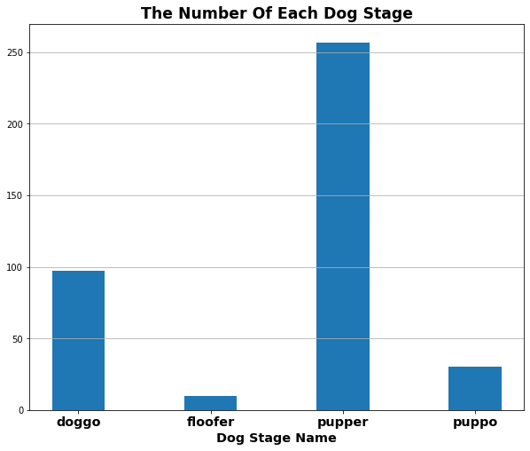

```python
number = [97,10,257,30]
dog_stage_names = Twitter_Archive.columns[8:]
plt.figure(figsize=(10,8))
plt.grid(True,axis='y')
plt.bar(dog_stage_names,number,width=0.4)
plt.title("The Number Of Each Dog Stage",fontsize='xx-large',fontweight='bold')
plt.xlabel("Dog Stage Name",fontweight='bold',fontsize='x-large')
plt.xticks(fontweight='bold',fontsize='x-large')
```

**General statistics about different dog stages ratings.**

```python
Twitter_Archive["Rating"] = Twitter_Archive["rating_numerator"]/Twitter_Archive['rating_denominator']
Twitter_Archive.info()
```

```
<class 'pandas.core.frame.DataFrame'>
RangeIndex: 2356 entries, 0 to 2355
Data columns (total 13 columns):
 #   Column              Non-Null Count  Dtype
---  ------              --------------  -----
 0   tweet_id            2356 non-null   object
 1   timestamp           2356 non-null   datetime64[ns, UTC]
 2   source              2356 non-null   object
 3   text                2356 non-null   object
 4   expanded_urls       2356 non-null   object
 5   rating_numerator    2356 non-null   int64
 6   rating_denominator  2356 non-null   int64
 7   name                1611 non-null   object
 8   doggo               97 non-null     object
 9   floofer             10 non-null     object
 10  pupper              257 non-null    object
 11  puppo               30 non-null     object
 12  Rating              2356 non-null   float64
dtypes: datetime64[ns, UTC](1), float64(1), int64(2), object(9)
memory usage: 239.4+ KB
```

```python
x = Twitter_Archive["Rating"].idxmax()
print(x)
Twitter_Archive.iloc[Twitter_Archive["Rating"].idxmax(),3]
```

```
313
```

```
"@jonnysun @Lin_Manuel ok jomny I know you're excited but 960/00 isn't a valid rating, 13/10 is tho"
```

```python
Twitter_Archive.iloc[Twitter_Archive["Rating"].idxmax(),5] = 13
Twitter_Archive.iloc[Twitter_Archive["Rating"].idxmax(),6] = 10
```

```python
Twitter_Archive["Rating"]= Twitter_Archive["rating_numerator"]/Twitter_Archive["rating_denominator"]
Twitter_Archive["Rating"].sort_values()
```

```
1016      0.0
315       0.0
1446      0.1
2261      0.1
1940      0.1
        ...
290      18.2
188      42.0
2074     42.0
189      66.6
979     177.6
Name: Rating, Length: 2356, dtype: float64
```

```python
a= Twitter_Archive.iloc[:,[12,8]].dropna()["Rating"]
```

```python
b= Twitter_Archive.iloc[:,[12,9]].dropna()["Rating"]
```

```python
c= Twitter_Archive.iloc[:,[12,10]].dropna()["Rating"]
```

```python
d= Twitter_Archive.iloc[:,[12,11]].dropna()["Rating"]
```

```python
x = {"doggo":a,"floofer":b,"pupper":c,"puppo":d}
```

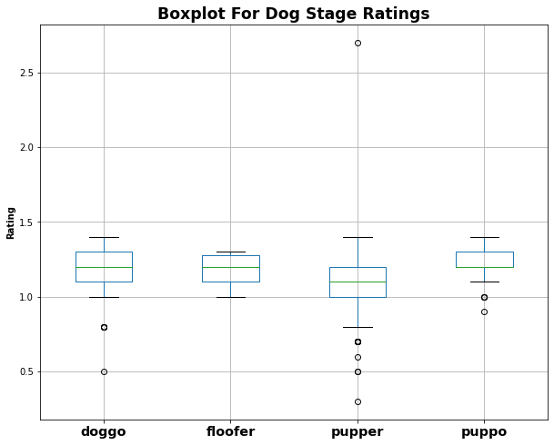

```python
df = pd.DataFrame(data=x)
plt.figure(figsize=(10,8))
plt.title("Boxplot For Dog Stage Ratings",fontsize='xx-large',fontweight='bold')
plt.ylabel("Rating",fontweight='bold',fontsize='medium')
plt.xticks(fontweight='bold',fontsize='x-large')
df.boxplot()
```

**General Statistics about dogs ratings**

```python
Twitter_Archive.iloc[Twitter_Archive["Rating"].idxmin(),5:]
```

```
rating_numerator        0
rating_denominator     10
name                  NaN
doggo                 NaN
floofer               NaN
pupper                NaN
puppo                 NaN
Rating                  0
Name: 315, dtype: object
```

```python
Twitter_Archive.iloc[Twitter_Archive["Rating"].idxmin(),3]
```

```
"When you're so blinded by your systematic plagiarism that you forget what day it is. 0/10 https://t.co/YbEJPkg4Ag"
```

0% is the least rating

```python
Twitter_Archive["Rating"].mode()
```

```
0    1.2
dtype: float64
```

```python
Twitter_Archive["Rating"].value_counts(sort=True)
```

```
1.200000      562
1.100000      469
1.000000      463
1.300000      352
0.900000      157
0.800000      102
0.700000       54
1.400000       54
0.500000       38
0.600000       32
0.300000       19
0.400000       15
0.200000       11
0.100000        8
42.000000       2
0.818182        2
1.500000        2
0.000000        2
7.500000        2
1.250000        1
66.600000       1
2.600000        1
177.600000      1
0.636364        1
18.200000       1
0.733333        1
1.700000        1
3.428571        1
2.700000        1
Name: Rating, dtype: int64
```

the most rating is 1.2 which has been given to a 562 dogs.

```python
Twitter_Archive["Rating"].median()
```

```
1.1
```

```python
Twitter_Archive.iloc[Twitter_Archive["Rating"].idxmax(),[3,5,6,7,8,9,10,11,12]]
```

```
text                  This is Atticus. He's quite simply America af....
rating_numerator                                                   1776
rating_denominator                                                   10
name                                                            Atticus
doggo                                                               NaN
floofer                                                             NaN
pupper                                                              NaN
puppo                                                               NaN
Rating                                                            177.6
Name: 979, dtype: object
```

the highest rating is 177.6

```python
Twitter_Archive["Rating"].describe()
```

```
count    2356.000000
mean        1.222065
std         4.082618
min         0.000000
25%         1.000000
50%         1.100000
75%         1.200000
max       177.600000
Name: Rating, dtype: float64
```

the average rating is 1.2

### Twitter Json

```python
Twitter_Json.info()
```

```
<class 'pandas.core.frame.DataFrame'>
RangeIndex: 2354 entries, 0 to 2353
Data columns (total 23 columns):
 #   Column                         Non-Null Count  Dtype
---  ------                         --------------  -----
 0   created_at                     2354 non-null   datetime64[ns, UTC]
 1   id                             2354 non-null   object
 2   full_text                      2354 non-null   object
 3   truncated                      2354 non-null   bool
 4   display_text_range             2354 non-null   object
 5   entities                       2354 non-null   object
 6   extended_entities              2073 non-null   object
 7   source                         2354 non-null   object
 8   in_reply_to_status_id          78 non-null     object
 9   in_reply_to_user_id            78 non-null     object
 10  in_reply_to_screen_name        78 non-null     object
 11  place                          1 non-null      object
 12  is_quote_status                2354 non-null   bool
 13  retweet_count                  2354 non-null   int64
 14  favorite_count                 2354 non-null   int64
 15  favorited                      2354 non-null   bool
 16  retweeted                      2354 non-null   bool
 17  possibly_sensitive             2211 non-null   float64
 18  possibly_sensitive_appealable  2211 non-null   float64
 19  lang                           2354 non-null   object
 20  retweeted_status               179 non-null    object
 21  quoted_status_id               29 non-null     object
 22  quoted_status                  28 non-null     object
dtypes: bool(4), datetime64[ns, UTC](1), float64(2), int64(2), object(14)
memory usage: 358.7+ KB
```

```python
Twitter_Json["retweet_count"].value_counts(sort=True)
```

```
1972     5
3652     5
83       5
146      4
61       4
        ..
8209     1
19       1
2068     1
30742    1
0        1
Name: retweet_count, Length: 1724, dtype: int64
```

the most common number *retweets* were [1972,3652,83] and it happened with 5 different tweets for each of them.

```python
Twitter_Json["retweet_count"].max()
```

```
79515
```

```python
#the full text of the tweet that got the highest number of retweets
Twitter_Json.iloc[Twitter_Json["retweet_count"].idxmax(),2]
```

```
"Here's a doggo realizing you can stand in a pool. 13/10 enlightened af (vid by Tina Conrad) https://t.co/7wE9LTEXC4"
```

```python
Twitter_Json.iloc[Twitter_Json["retweet_count"].idxmax(),[2,13]]
```

```
full_text        Here's a doggo realizing you can stand in a po...
retweet_count                                                79515
Name: 1037, dtype: object
```

the highest number of reweets for a given tween was 79515.

```python
Twitter_Json["retweet_count"].describe()
```

```
count     2354.000000
mean      3164.797366
std       5284.770364
min          0.000000
25%        624.500000
50%       1473.500000
75%       3652.000000
max      79515.000000
Name: retweet_count, dtype: float64
```

the median for the retweets was 1473 and the average was 3164

- This document is created by [**Yousef Mohammed Saber**](https://github.com/YousefSaber).